# SNA HITS 17_ACESSO I) O tempo gasto para acessar este serviço impede a realização ativades em conjunto. (var15)

Leonardo Martins

17 de julho de 2016

SNA Descritive Analysis from “Projeto Redes de Atenção às pessoas que consomem álcool e outras Drogas em Juiz de Fora-MG Brazil” - SNArRDJF

Here you can find a basic script to analysis data from SNArRDJF - this script was elaborated considering its use for orther matrix adjacency data from SNArRDJF - Here we are going to analyse:

# 1 17_ACESSO I) O tempo gasto para acessar este serviço impede a realização ativades em conjunto. (var15)

# 2 Loading objects generated with previous script

```r
rm(list = ls()) # removing previous objects to be sure that we don't have objects conflicts name
load("~/SNArRDJF/Robject/6_bonacichs_var15.RData")
```

## 2.1 Reload packages

```r
suppressMessages(library(RColorBrewer))
suppressMessages(library(car))
suppressMessages(library(xtable))
suppressMessages(library(igraph))
suppressMessages(library(miniCRAN))
suppressMessages(library(magrittr))
suppressMessages(library(keyplayer))
suppressMessages(library(dplyr))
suppressMessages(library(feather))
suppressMessages(library(visNetwork))
suppressMessages(library(knitr))
suppressMessages(library(DT))
```

## 2.2 Adding phantom tools

```r
#In order to get dinamic javascript object install those ones. If you get problems installing go to Stackoverflow.com and type your error to discover what to do. In some cases the libraries need to be intalled in outside R libs.
#devtools::install_github("wch/webshot")
#webshot::install_phantomjs()
```

## 2.3 Setting a random seed - this is a good strategy to keep the same graph pattern layout in a new report generation

```r
set.seed(123)
```

## 2.4 Simplify Graph - removing loops and duble edges

```r
#var15<-simplify(var15) #Simplify
```

# 3 Hubs and Authorities (HITS)

Hyperlink-Induced Topic Search (HITS; also known as hubs and authorities) is a link analysis algorithm that rates Web pages, developed by Jon Kleinberg.

The idea behind Hubs and Authorities stemmed from a particular insight into the creation of web pages when the Internet was originally forming; that is, certain web pages, known as hubs, served as large directories that were not actually authoritative in the information that they held, but were used as compilations of a broad catalog of information that led users direct to other authoritative pages. In other words, a good hub represented a page that pointed to many other pages, and a good authority represented a page that was linked by many different hubs.(from dirty wikipedia)

The scheme therefore assigns two scores for each page: its authority, which estimates the value of the content of the page, and its hub value, which estimates the value of its links to other pages.

We can use the same analogy for citation networks like reviews (hubs) vs original research (authoritative) papers

• Authorities, contain useful information

• Hubs, contains links to authorities

• Good authorities referred by good hubs

• Good hubs point to good authorities

It is possibile to apply this kind of analysis for social network relationships.

## 3.1 Hubs - are expected to contain catalogs with a large number of outgoing links;

```r
#Kleinberg’s hub scores
V(var15)$hub <- hub.score(var15)$vector
var15_hub<- hub.score(var15)$vector %>% round(4)
```

## 3.2 Hubs Table

```r
d=as.data.frame(cbind(V(var15)$LABEL_COR, var15_hub))
names(d)<-c("Type", "Hub Score")
datatable(d, filter ="top")
```

|  | Type | Hub Score |
| --- | --- | --- |
| ASS_HOS_ Hospital de Pronto Socorro – HPS | Assistência Hospitalar | 0 |
| AMB_SAM_ Centro de Atenção à Saúde Mental (CASM) | Ambulatório de Saúde Mental | 0.5755 |
| CAPS_AD | CAPSAD | 1 |
| CRAS_AS_ CRAS Sudeste Costa Carvalho | CRAS/CREAS | 0.1606 |
| CRE_SOC_ CREAS Infância e Juventude | CRAS/CREAS | 0.1971 |
| CRE_SOC_ CREAS Norte | CRAS/CREAS | 0.2599 |
| ASS_HOS_ Serviço de Controle e Prevenção e Tratamento do Tabagismo (SECOPTT) | Assistência Hospitalar | 0.2374 |
| EA_DQCT_ Centro de Recuperação Resgatando Vidas (Escritório) | Entidades Assistênciais e Dependencia Química e CT | 0 |
| EA_DQCT_ Comunidade Terapêutica Geração de Adoradores – CTGA | Entidades Assistênciais e Dependencia Química e CT | 0 |
| EA_DQCT_ Centro de Recuperação Resgatando Vidas | Entidades Assistênciais e Dependencia Química e CT | 0.0472 |

[output cut: 177 more lines]

##Hubs Stats

```r
summary(var15_hub)
```

```
##    Min. 1st Qu.  Median    Mean 3rd Qu.    Max.
## 0.00000 0.00000 0.00000 0.05640 0.06045 1.00000
```

```r
sd(var15_hub)
```

```
## [1] 0.1226304
```

## 3.3 Plotting based on Hub Scores

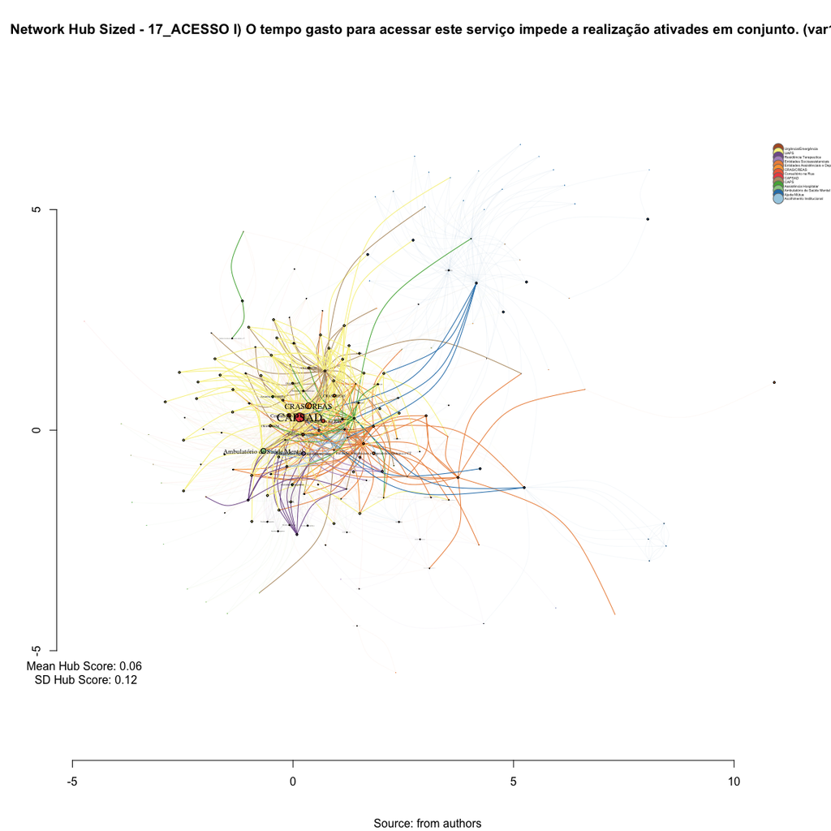

```r
set.seed(123)
#Plotting based only on degree measures
edge.start <- ends(var15, es=E(var15), names=F)[,1]

# Fixing ego
minC <- rep(-Inf, vcount(var15))
maxC <- rep(Inf, vcount(var15))
minC[1] <- maxC[1] <- 0
co <- layout_with_fr(var15, niter=10^4, minx=minC, maxx=maxC,miny=minC, maxy=maxC, weights = E(var15)$weight)

#Plotting
plot(var15,
     layout=co,
     edge.color=V(total)$color[edge.start],
     edge.arrow.size=(hub.score(var15)$vector+0.001)/100,
     edge.width=E(var15)$weight/10*mean(E(var15)$weight),
     edge.curved = TRUE,
     vertex.color=V(var15)$color,
     vertex.size=20*hub.score(var15)$vector,
     vertex.frame.color="black",
     vertex.label.color="black",
     vertex.label=get.vertex.attribute(var15,"LABEL_COR"),
     vertex.label.cex=(hub.score(var15)$vector+0.001),
     vertex.label.dist=0,
     rescale=F,
     xlim=range(co[,1]),
     ylim=range(co[,2])
     )
axis(1)
axis(2)


#Solving Problems with legend rendering
a<-V(total)$LABEL_COR
b<-V(total)$color
c<-table(a,b)
d<-as.data.frame(c)
e<-subset(d, d$Freq>0)
e<-e[order(e$a,decreasing=T),]
f<-t(e$a)
g<-t(e$b)

#Adding Legend
legend(x=range(co[,1])[2],
       y=range(co[,2])[2],
       legend=as.character(f),
       pch=21,
       col = "#777777",
       pt.bg=as.character(g),
       pt.cex=2,
       bty="n",
       ncol=1,
       lty=1,
       cex = .3)

#Adding Title
  title("Network Hub Sized - 17_ACESSO I) O tempo gasto para acessar este serviço impede a realização ativades em conjunto. (var15)", sub = "Source: from authors ")
  text(
    x=range(co[,1])[1],
    y=range(co[,2])[1],
      labels =    sprintf("Mean Hub Score: %.2f\n SD Hub Score: %.2f",
     mean(var15_hub),
     sd(var15_hub)
             )
       )
```

# 4 Authorities - would get many incoming links from hubs, presumably because of their high-quality relevant information.

```r
#Kleinberg’s authority scores
V(var15)$authority.score<- authority.score(var15)$vector
var15_auth <- authority.score(var15)$vector %>% round(4)
```

## 4.1 Authorities Table

```r
d=as.data.frame(cbind(V(var15)$LABEL_COR, var15_auth))
names(d)<-c("Type", "Authorities Score")
datatable(d, filter ="top")
```

|  | Type | Authorities Score |
| --- | --- | --- |
| ASS_HOS_ Hospital de Pronto Socorro – HPS | Assistência Hospitalar | 0.7779 |
| AMB_SAM_ Centro de Atenção à Saúde Mental (CASM) | Ambulatório de Saúde Mental | 0.3304 |
| CAPS_AD | CAPSAD | 1 |
| CRAS_AS_ CRAS Sudeste Costa Carvalho | CRAS/CREAS | 0.3597 |
| CRE_SOC_ CREAS Infância e Juventude | CRAS/CREAS | 0.4679 |
| CRE_SOC_ CREAS Norte | CRAS/CREAS | 0.4092 |
| ASS_HOS_ Serviço de Controle e Prevenção e Tratamento do Tabagismo (SECOPTT) | Assistência Hospitalar | 0.2267 |
| EA_DQCT_ Centro de Recuperação Resgatando Vidas (Escritório) | Entidades Assistênciais e Dependencia Química e CT | 0.21 |
| EA_DQCT_ Comunidade Terapêutica Geração de Adoradores – CTGA | Entidades Assistênciais e Dependencia Química e CT | 0.0323 |
| EA_DQCT_ Centro de Recuperação Resgatando Vidas | Entidades Assistênciais e Dependencia Química e CT | 0.1201 |

[output cut: 177 more lines]

##Authorities Stats

```r
summary(var15_auth)
```

```
##    Min. 1st Qu.  Median    Mean 3rd Qu.    Max.
## 0.00000 0.02705 0.14260 0.15320 0.20530 1.00000
```

```r
sd(var15_auth)
```

```
## [1] 0.1491051
```

## 4.2 Plotting based only on Authorities Scores

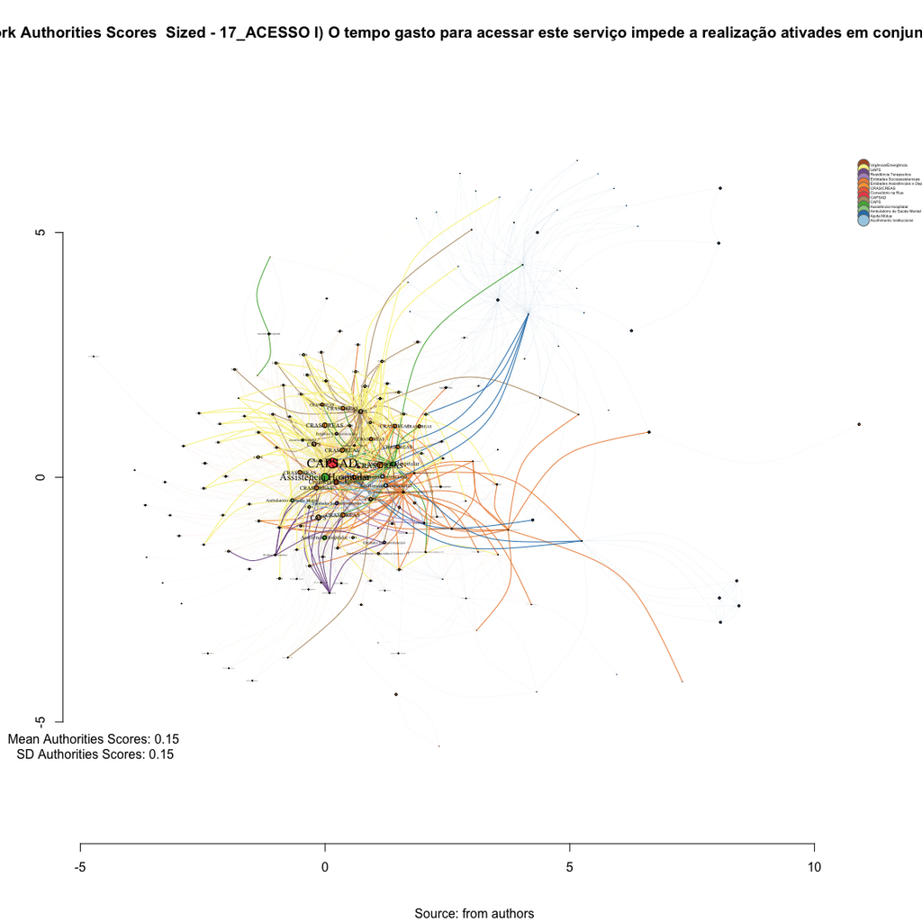

```r
set.seed(123)
#Plotting based only on degree measures
edge.start <- ends(var15, es=E(var15), names=F)[,1]

# Fixing ego
minC <- rep(-Inf, vcount(var15))
maxC <- rep(Inf, vcount(var15))
minC[1] <- maxC[1] <- 0
co <- layout_with_fr(var15, niter=10^4, minx=minC, maxx=maxC,miny=minC, maxy=maxC, weights = E(var15)$weight)

#Plotting
plot(var15,
     layout=co,
     edge.color=V(total)$color[edge.start],
     edge.arrow.size=(authority.score(var15)$vector+0.01)/100,
     edge.width=E(var15)$weight/10*mean(E(var15)$weight),
     edge.curved = TRUE,
     vertex.color=V(var15)$color,
     vertex.size=20*authority.score(var15)$vector,
     vertex.frame.color="black",
     vertex.label.color="black",
     vertex.label=get.vertex.attribute(var15,"LABEL_COR"),
     vertex.label.cex=(authority.score(var15)$vector+0.01),
     vertex.label.dist=0,
     rescale=F,
     xlim=range(co[,1]),
     ylim=range(co[,2])
     )
axis(1)
axis(2)

#Solving Problems with legend rendering
a<-V(total)$LABEL_COR
b<-V(total)$color
c<-table(a,b)
d<-as.data.frame(c)
e<-subset(d, d$Freq>0)
e<-e[order(e$a,decreasing=T),]
f<-t(e$a)
g<-t(e$b)

#Adding Legend
legend(x=range(co[,1])[2],
       y=range(co[,2])[2],
       legend=as.character(f),
       pch=21,
       col = "#777777",
       pt.bg=as.character(g),
       pt.cex=2,
       bty="n",
       ncol=1,
       lty=1,
       cex = .3)

#Adding Title
  title("Network Authorities Scores  Sized - 17_ACESSO I) O tempo gasto para acessar este serviço impede a realização ativades em conjunto. (var15)", sub = "Source: from authors ")
  text(
    x=range(co[,1])[1],
    y=range(co[,2])[1],
      labels =    sprintf("Mean Authorities Scores: %.2f\n SD Authorities Scores: %.2f",
     mean(var15_auth),
     sd(var15_auth)
             )
       )
```

# 5 Google PageRank - it is what it is

```r
#PageRank
V(var15)$page.rank<-page.rank(var15)$vector
var15_pr<-page.rank(var15)$vector %>% round(4)
```

## 5.1 PageRank Table

```r
d=as.data.frame(cbind(V(var15)$LABEL_COR, var15_pr))
names(d)<-c("Type", "Page Rank")
datatable(d, filter ="top")
```

|  | Type | Page Rank |
| --- | --- | --- |
| ASS_HOS_ Hospital de Pronto Socorro – HPS | Assistência Hospitalar | 0.0299 |
| AMB_SAM_ Centro de Atenção à Saúde Mental (CASM) | Ambulatório de Saúde Mental | 0.0149 |
| CAPS_AD | CAPSAD | 0.0509 |
| CRAS_AS_ CRAS Sudeste Costa Carvalho | CRAS/CREAS | 0.0063 |
| CRE_SOC_ CREAS Infância e Juventude | CRAS/CREAS | 0.0081 |
| CRE_SOC_ CREAS Norte | CRAS/CREAS | 0.0072 |
| ASS_HOS_ Serviço de Controle e Prevenção e Tratamento do Tabagismo (SECOPTT) | Assistência Hospitalar | 0.0064 |
| EA_DQCT_ Centro de Recuperação Resgatando Vidas (Escritório) | Entidades Assistênciais e Dependencia Química e CT | 0.0067 |
| EA_DQCT_ Comunidade Terapêutica Geração de Adoradores – CTGA | Entidades Assistênciais e Dependencia Química e CT | 0.0028 |
| EA_DQCT_ Centro de Recuperação Resgatando Vidas | Entidades Assistênciais e Dependencia Química e CT | 0.0065 |

[output cut: 177 more lines]

## 5.2 PageRank Stats

```r
summary(var15_pr)
```

```
##     Min.  1st Qu.   Median     Mean  3rd Qu.     Max.
## 0.002500 0.003100 0.003900 0.005346 0.005700 0.050900
```

```r
sd(var15_pr)
```

```
## [1] 0.004889678
```

## 5.3 Plotting based only on PageRank Scores

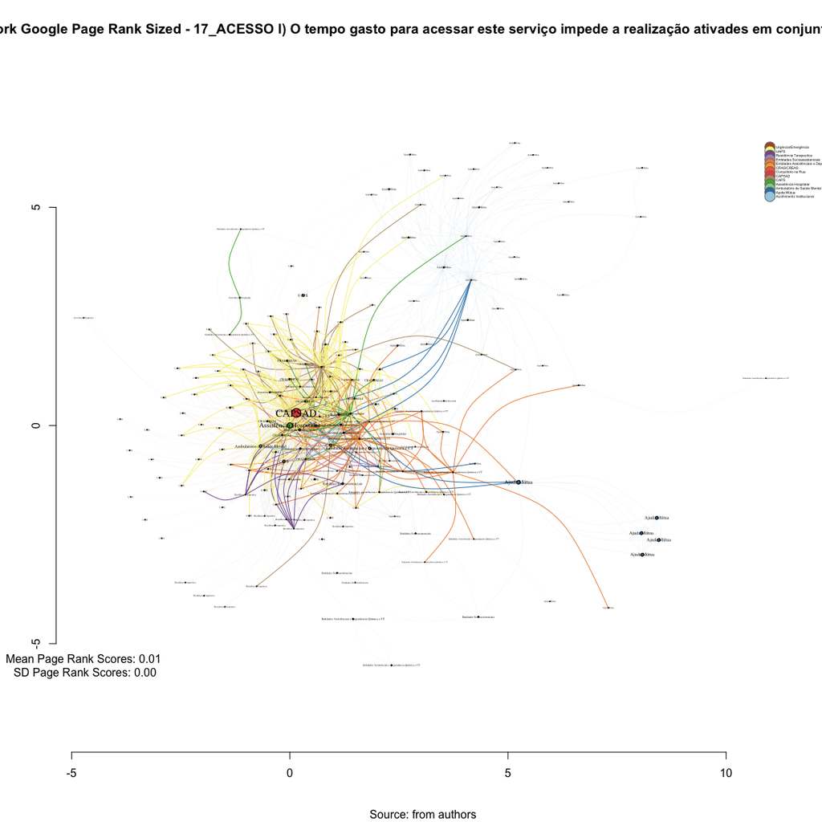

```r
set.seed(123)
#Plotting based only on degree measures
edge.start <- ends(var15, es=E(var15), names=F)[,1]

# Fixing ego
minC <- rep(-Inf, vcount(var15))
maxC <- rep(Inf, vcount(var15))
minC[1] <- maxC[1] <- 0
co <- layout_with_fr(var15, niter=10^4, minx=minC, maxx=maxC,miny=minC, maxy=maxC, weights = E(var15)$weight)

#Plotting
plot(var15,
     layout=co,
     edge.color=V(total)$color[edge.start],
     edge.arrow.size=(page.rank(var15)$vector+0.01)/100,
     edge.width=E(var15)$weight/10*mean(E(var15)$weight),
     edge.curved = TRUE,
     vertex.color=V(var15)$color,
     vertex.size=400*page.rank(var15)$vector,
     vertex.frame.color="black",
     vertex.label.color="black",
     vertex.label=get.vertex.attribute(var15,"LABEL_COR"),
     vertex.label.cex=15*(page.rank(var15)$vector+0.01),
     vertex.label.dist=0,
     rescale=F,
     xlim=range(co[,1]),
     ylim=range(co[,2])
     )
axis(1)
axis(2)


#Solving Problems with legend rendering
a<-V(total)$LABEL_COR
b<-V(total)$color
c<-table(a,b)
d<-as.data.frame(c)
e<-subset(d, d$Freq>0)
e<-e[order(e$a,decreasing=T),]
f<-t(e$a)
g<-t(e$b)

#Adding Legend
legend(x=range(co[,1])[2],
       y=range(co[,2])[2],
       legend=as.character(f),
       pch=21,
       col = "#777777",
       pt.bg=as.character(g),
       pt.cex=2,
       bty="n",
       ncol=1,
       lty=1,
       cex = .3)

#Adding Title
  title("Network Google Page Rank Sized - 17_ACESSO I) O tempo gasto para acessar este serviço impede a realização ativades em conjunto. (var15)", sub = "Source: from authors ")
  text(
    x=range(co[,1])[1],
    y=range(co[,2])[1],
      labels =    sprintf("Mean Page Rank Scores: %.2f\n SD Page Rank Scores: %.2f",
     mean(var15_pr),
     sd(var15_pr)
             ))
```

# 6 Saving HITS and Degree

```r
# We will plot 6 graphs in 2 rows and 3 columns:
prPB<-page_rank(var15)$vector
hPB<-hub.score(var15)$vector
authPB<-authority.score(var15)$vector
indegPB<-degree(var15, mode="in")
outdegPB<-degree(var15, mode="out")
```

## 6.1 Plotting all together

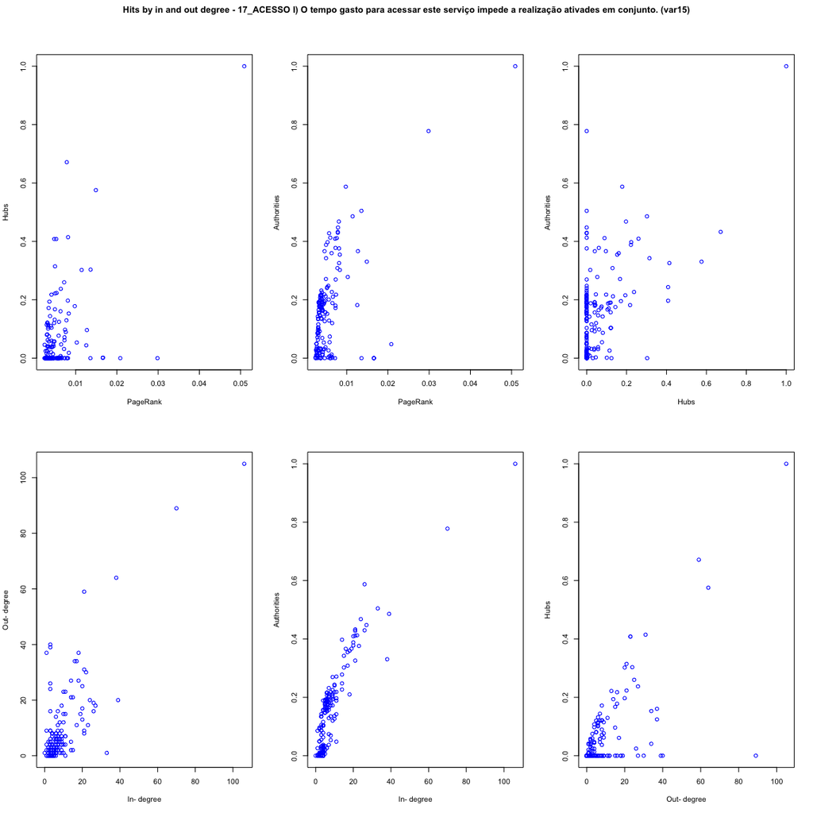

```r
op <- par(mfrow = c(2, 3),oma=c(0,0,2,0))
plot(prPB, hPB, xlab="PageRank", ylab="Hubs", col="blue")
plot(prPB, authPB, xlab="PageRank", ylab="Authorities", col="blue")
plot(hPB, authPB, xlab="Hubs", ylab="Authorities", col="blue")
plot(indegPB, outdegPB, xlab="In- degree", ylab="Out- degree", col="blue")
plot(indegPB, authPB, xlab="In- degree", ylab="Authorities", col="blue")
plot(outdegPB, hPB, xlab="Out- degree", ylab="Hubs", col="blue")
title("Hits by in and out degree - 17_ACESSO I) O tempo gasto para acessar este serviço impede a realização ativades em conjunto. (var15)", outer=TRUE)
```

```r
par(op)
```

## 6.2 Top HITs

```r
##Create a matrix to output:
topnamesPB=as.data.frame(cbind(prPB,hPB,authPB,indegPB,outdegPB)) %>% round(4)
names(topnamesPB) <- c("PageRank","Hubs","Authorities","In- degree","Out- degree")
```

## 6.3 HITS Table

```r
datatable(topnamesPB, filter = "top")
```

|  | PageRank | Hubs | Authorities | In- degree | Out- degree |
| --- | --- | --- | --- | --- | --- |
| ASS_HOS_ Hospital de Pronto Socorro – HPS | 0.0299 | 0 | 0.7779 | 70 | 89 |
| AMB_SAM_ Centro de Atenção à Saúde Mental (CASM) | 0.0149 | 0.5755 | 0.3304 | 38 | 64 |
| CAPS_AD | 0.0509 | 1 | 1 | 106 | 105 |
| CRAS_AS_ CRAS Sudeste Costa Carvalho | 0.0063 | 0.1606 | 0.3597 | 18 | 37 |
| CRE_SOC_ CREAS Infância e Juventude | 0.0081 | 0.1971 | 0.4679 | 24 | 20 |
| CRE_SOC_ CREAS Norte | 0.0072 | 0.2599 | 0.4092 | 20 | 25 |
| ASS_HOS_ Serviço de Controle e Prevenção e Tratamento do Tabagismo (SECOPTT) | 0.0064 | 0.2374 | 0.2267 | 14 | 27 |
| EA_DQCT_ Centro de Recuperação Resgatando Vidas (Escritório) | 0.0067 | 0 | 0.21 | 18 | 27 |
| EA_DQCT_ Comunidade Terapêutica Geração de Adoradores – CTGA | 0.0028 | 0 | 0.0323 | 3 | 16 |
| EA_DQCT_ Centro de Recuperação Resgatando Vidas | 0.0065 | 0.0472 | 0.1201 | 9 | 4 |

[output cut: 177 more lines]

# 7 Saving objects with new variables and changes

```r
save.image("~/SNArRDJF/Robject/7_hits_var15.RData")
```